# Project: Female labour force participation around the the globe

- Introduction
- Data Wrangling
- Exploratory Data Analysis
- Conclusions

## Introduction

Female Labour Participation Rates (FLPR) measure the percentages of the working female population in relation to the country's total female population. Several sources verify that female labour force participation are substantially lower than male labour participation almost everywhere in the world (ILO, World Bank). Regardless of the male labour force participation, the percentage of women working can vary significantly across the globe.

Throughout the report I will investigate female labour participation geographically and how it may have changed over time. Further, I'm going to analyse to what extend a country's economic situation may determine if women engage in the labour market.

```python
# Import packages
import pandas as pd
# allow to show complete tables throughout the notebook
from IPython.display import display
pd.options.display.max_columns = None
from functools import reduce
import numpy as np
import matplotlib.pyplot as plt
import seaborn as sns
%matplotlib inline
```

## Data Wrangling

The data used in this report comes from csv files, I downloaded from the Gapminder platform. Gapminder provides socio-economic and political statistics and information coming from third party databases like ilostat, World Bank, esa. Below, I will introduce the data and variables I will be using throughout the explorative analysis.

https://www.gapminder.org/data/

### Load Datasets

```python
# load female labour force participation rates
df_flpr = pd.read_csv('./female_labour_15+.csv')
# load GNI per capita
df_gni = pd.read_csv('./gnipercapita.csv')
# load list of countries and their categories
df_countries = pd.read_csv('./countries_by_category.csv')
# load female population by country
df_pop = pd.read_csv('./female_population.csv')
# load female agriculture employment
df_agr = pd.read_csv('./female_agriculture_workers.csv')
# load female industry employment
df_ind = pd.read_csv('./female_industry_workers.csv')
# load female service employment
df_serv = pd.read_csv('./female_service_workers.csv')
```

### Properties Female Labour Participation Rates (FLPR)

Source: Gapminder, provided by International Labour Organization (ilostat)

**Description**  
Central to this report are labour force participation rates of females aged over 15 years in countries around the globe. It states the percentage of the working female population in relation to the country's total female population. The FLPR counts all working females or females who are actively looking for labour. That includes self-employed and unemployed females. FLPRs are likely to be underestimated as 'female' work (e.g. care work) is often not considered as employment. https://www.ilo.org/ilostat-files/Documents/description_LFPR_EN.pdf

```python
df_flpr.head(3)
```

|  | country | 1990 | 1991 | 1992 | 1993 | 1994 | 1995 | 1996 | 1997 | 1998 | 1999 | 2000 | 2001 | 2002 | 2003 | 2004 | 2005 | 2006 | 2007 | 2008 | 2009 | 2010 | 2011 | 2012 | 2013 | 2014 | 2015 | 2016 | 2017 |
| --- | --- | --- | --- | --- | --- | --- | --- | --- | --- | --- | --- | --- | --- | --- | --- | --- | --- | --- | --- | --- | --- | --- | --- | --- | --- | --- | --- | --- | --- |
| 0 | Afghanistan | 14.8 | 14.9 | 14.9 | 14.9 | 14.9 | 15.0 | 14.8 | 14.7 | 14.6 | 14.5 | 14.5 | 14.8 | 15.2 | 15.5 | 15.8 | 16.1 | 15.7 | 15.2 | 14.9 | 14.7 | 14.7 | 15.3 | 16.0 | 16.9 | 17.8 | 18.7 | 19.4 | 19.5 |
| 1 | Albania | 53.6 | 55.8 | 56.1 | 55.3 | 54.5 | 53.5 | 52.9 | 53.6 | 53.0 | 52.2 | 51.7 | 51.1 | 50.7 | 49.8 | 48.9 | 48.1 | 47.4 | 46.8 | 46.3 | 44.9 | 45.7 | 47.1 | 48.8 | 44.6 | 44.8 | 47.7 | 47.4 | 47.2 |
| 2 | Algeria | 11.5 | 11.5 | 11.6 | 11.6 | 11.7 | 11.8 | 11.9 | 11.8 | 11.8 | 11.8 | 11.9 | 12.0 | 12.2 | 12.4 | 12.6 | 12.8 | 13.1 | 13.5 | 13.8 | 14.2 | 14.4 | 15.2 | 16.2 | 16.9 | 15.3 | 15.2 | 15.1 | 15.2 |

```python
df_flpr.info()
```

```
<class 'pandas.core.frame.DataFrame'>
RangeIndex: 178 entries, 0 to 177
Data columns (total 29 columns):
country    178 non-null object
1990       178 non-null float64
1991       178 non-null float64
1992       178 non-null float64
1993       178 non-null float64
1994       178 non-null float64
1995       178 non-null float64
1996       178 non-null float64
1997       178 non-null float64
1998       178 non-null float64
1999       178 non-null float64
2000       178 non-null float64
```

[output cut: 19 more lines]

### Gross National Income per Capita (GNI)

Source: Gapminder, provided by World Bank

**Description**  
To evaluate the world economy by country, I'm investigating the Gross National Incomes of countries (GNI), provided by the World Bank. It measures the country's income per capita. The GNI is closely related to the GDP. In contrast to the GDP, it includes all compensations paid to domestic residents by foreign businesses. Subsidies and paid compensations to overseas residents are subtracted. Product and income taxes are also included in the GNI. The GNI is calculated in national currency and converted to U.S. dollars at official exchange rates. The data set uses the 'Atlas method' to smooth out fluctuations in prices and exchange rates. https://data.worldbank.org/indicator/NY.GNP.PCAP.CD

**Properties**  
We got GNI values by country for the years 1962 to 2017. The data of a country is of type string and the GNI comes as a float, which makes up for 56 years. Many rows contain null values.

```python
df_gni.head()
```

|  | country | 1962 | 1963 | 1964 | 1965 | 1966 | 1967 | 1968 | 1969 | 1970 | 1971 | 1972 | 1973 | 1974 | 1975 | 1976 | 1977 | 1978 | 1979 | 1980 | 1981 | 1982 | 1983 | 1984 | 1985 | 1986 | 1987 | 1988 | 1989 | … |
| --- | --- | --- | --- | --- | --- | --- | --- | --- | --- | --- | --- | --- | --- | --- | --- | --- | --- | --- | --- | --- | --- | --- | --- | --- | --- | --- | --- | --- | --- | --- |
| 0 | Afghanistan | NaN | NaN | NaN | NaN | NaN | NaN | NaN | NaN | NaN | NaN | NaN | NaN | NaN | NaN | NaN | NaN | NaN | NaN | NaN | NaN | NaN | NaN | NaN | NaN | NaN | NaN | NaN | NaN | … |
| 1 | Albania | NaN | NaN | NaN | NaN | NaN | NaN | NaN | NaN | NaN | NaN | NaN | NaN | NaN | NaN | NaN | NaN | NaN | NaN | NaN | NaN | NaN | NaN | NaN | NaN | 720.0 | 760.0 | 760.0 | 790.0 | … |
| 2 | Algeria | 190.0 | 230.0 | 240.0 | 240.0 | 230.0 | 250.0 | 280.0 | 310.0 | 330.0 | 310.0 | 430.0 | 530.0 | 710.0 | 910.0 | 1050.0 | 1140.0 | 1350.0 | 1670.0 | 2010.0 | 2220.0 | 2280.0 | 2210.0 | 2260.0 | 2390.0 | 2590.0 | 2810.0 | 2750.0 | 2540.0 | … |
| 3 | Angola | NaN | NaN | NaN | NaN | NaN | NaN | NaN | NaN | NaN | NaN | NaN | NaN | NaN | NaN | NaN | NaN | NaN | NaN | NaN | NaN | NaN | NaN | NaN | 560.0 | 640.0 | 630.0 | 630.0 | 830.0 | … |
| 4 | Antigua and Barbuda | NaN | NaN | NaN | NaN | NaN | NaN | NaN | NaN | NaN | NaN | NaN | NaN | NaN | NaN | NaN | NaN | NaN | 1520.0 | 1830.0 | 2060.0 | 2110.0 | 2320.0 | 2770.0 | 3200.0 | 3560.0 | 4440.0 | 5560.0 | 6000.0 | … |

```python
df_gni.info()
```

```
<class 'pandas.core.frame.DataFrame'>
RangeIndex: 190 entries, 0 to 189
Data columns (total 57 columns):
country    190 non-null object
1962       73 non-null float64
1963       74 non-null float64
1964       75 non-null float64
1965       75 non-null float64
1966       75 non-null float64
1967       82 non-null float64
1968       87 non-null float64
1969       89 non-null float64
1970       92 non-null float64
1971       93 non-null float64
1972       102 non-null float64
```

[output cut: 47 more lines]

### Female Population

Source: Gapminder, provided by esa

**Description**  
This datasets includes the total numbers of a country's female population over the years. Values after 2010 are based on medium estimates from the UN population devision.

**Properties**  
We got the total female population numbers over the years 1950 to 2100 of 184 countries. Countries are of type string and the population numbers are of type integer. No null values.

```python
df_pop.head()
```

|  | country | 1950 | 1951 | 1952 | 1953 | 1954 | 1955 | 1956 | 1957 | 1958 | 1959 | 1960 | 1961 | 1962 | 1963 | 1964 | 1965 | 1966 | 1967 | 1968 | 1969 | 1970 | 1971 | 1972 | 1973 | 1974 | 1975 | 1976 | 1977 | … |
| --- | --- | --- | --- | --- | --- | --- | --- | --- | --- | --- | --- | --- | --- | --- | --- | --- | --- | --- | --- | --- | --- | --- | --- | --- | --- | --- | --- | --- | --- | --- |
| 0 | Afghanistan | 3650000 | 3710000 | 3760000 | 3820000 | 3880000 | 3950000 | 4020000 | 4100000 | 4180000 | 4260000 | 4350000 | 4440000 | 4530000 | 4630000 | 4730000 | 4840000 | 4950000 | 5070000 | 5190000 | 5310000 | 5450000 | 5600000 | 5750000 | 5910000 | 6060000 | 6190000 | 6320000 | 6430000 | … |
| 1 | Albania | 615000 | 626000 | 640000 | 655000 | 672000 | 690000 | 709000 | 728000 | 749000 | 771000 | 794000 | 818000 | 843000 | 869000 | 895000 | 920000 | 945000 | 970000 | 994000 | 1020000 | 1040000 | 1070000 | 1090000 | 1120000 | 1150000 | 1170000 | 1200000 | 1220000 | … |
| 2 | Algeria | 4360000 | 4450000 | 4550000 | 4650000 | 4760000 | 4870000 | 4990000 | 5120000 | 5250000 | 5390000 | 5530000 | 5670000 | 5810000 | 5960000 | 6120000 | 6290000 | 6460000 | 6650000 | 6840000 | 7040000 | 7240000 | 7440000 | 7640000 | 7850000 | 8070000 | 8300000 | 8530000 | 8780000 | … |
| 3 | Angola | 2340000 | 2400000 | 2460000 | 2520000 | 2570000 | 2630000 | 2690000 | 2740000 | 2790000 | 2850000 | 2900000 | 2960000 | 3010000 | 3070000 | 3130000 | 3190000 | 3240000 | 3290000 | 3350000 | 3410000 | 3480000 | 3550000 | 3640000 | 3730000 | 3830000 | 3930000 | 4050000 | 4160000 | … |
| 4 | Antigua and Barbuda | 23500 | 24300 | 25000 | 25600 | 26200 | 26700 | 27300 | 27800 | 28300 | 28800 | 29300 | 29800 | 30300 | 30800 | 31300 | 31900 | 32500 | 33100 | 33800 | 34400 | 35000 | 35600 | 36100 | 36600 | 37000 | 37300 | 37500 | 37700 | … |

```python
df_pop.info()
```

```
<class 'pandas.core.frame.DataFrame'>
RangeIndex: 184 entries, 0 to 183
Columns: 152 entries, country to 2100
dtypes: int64(151), object(1)
memory usage: 218.6+ KB
```

### Countries by Category

Source: Wikimedia, https://meta.wikimedia.org/wiki/List_of_countries_by_regional_classification

*Description*  
To evaluate the datasets by a world's region, I parsed countries and their corresponding region and development status from Wikimedia into a csv file. In the process of data cleaning, I matched differing country names to names used in the other datasets.

*Properties*  
The dataset consists of 247 entries for country's with their corresponding world region and development status. All data is provided in the data format of a string.

```python
df_countries.info()
```

```
<class 'pandas.core.frame.DataFrame'>
RangeIndex: 247 entries, 0 to 246
Data columns (total 3 columns):
Country        247 non-null object
Region         247 non-null object
Development    247 non-null object
dtypes: object(3)
memory usage: 5.9+ KB
```

### Female Employment by Sector (% Female Employment)

Source: Gapminder, provided by ilostat

*Female Agriculture Workers (% Female Employment)*  
Percentage of women working in the agricultural sector.

*Female Industry Workers (% Female Employment)*  
Percentage of women working in the industrial sector.

*Female Service Workers (% Female Employment)*  
Percentage of women working in the service sector.

*Properties*  
All employment sector datasets consist of 179 countries covering the years 1991 to 2022. Countries come in the data format of a string. Every year contains a percentage value of a float. No null values.

```python
df_agr.info()
```

```
<class 'pandas.core.frame.DataFrame'>
RangeIndex: 179 entries, 0 to 178
Data columns (total 33 columns):
country    179 non-null object
1991       179 non-null float64
1992       179 non-null float64
1993       179 non-null float64
1994       179 non-null float64
1995       179 non-null float64
1996       179 non-null float64
1997       179 non-null float64
1998       179 non-null float64
1999       179 non-null float64
2000       179 non-null float64
2001       179 non-null float64
```

[output cut: 23 more lines]

```python
df_ind.info()
```

```
<class 'pandas.core.frame.DataFrame'>
RangeIndex: 179 entries, 0 to 178
Data columns (total 33 columns):
country    179 non-null object
1991       179 non-null float64
1992       179 non-null float64
1993       179 non-null float64
1994       179 non-null float64
1995       179 non-null float64
1996       179 non-null float64
1997       179 non-null float64
1998       179 non-null float64
1999       179 non-null float64
2000       179 non-null float64
2001       179 non-null float64
```

[output cut: 23 more lines]

```python
df_serv.info()
```

```
<class 'pandas.core.frame.DataFrame'>
RangeIndex: 179 entries, 0 to 178
Data columns (total 33 columns):
country    179 non-null object
1991       179 non-null float64
1992       179 non-null float64
1993       179 non-null float64
1994       179 non-null float64
1995       179 non-null float64
1996       179 non-null float64
1997       179 non-null float64
1998       179 non-null float64
1999       179 non-null float64
2000       179 non-null float64
2001       179 non-null float64
```

[output cut: 23 more lines]

The data wrangling showed the data comes already in appropriate data formats. We got recorded yearly data without gaps. The smallest number of recorded countries is the FLPR data containing 178 countries. Since there are currently 195 countries in the world, our dataset covers the great majority of the globe. Nevertheless, there are four key findings, I have to pay attention to throughout the following data cleaning process.

**Time frame**  
The data wrangling uncovered the years 1991 to 2017 to be in common across all datasets. It makes sense to focus on the time frame of common data, so I'm going to drop values of earlier or later years.

**Countries**  
I noticed that some of the datasets include different countries than others. Throughout the analysis I want to make sure to compare a set of matching countries. Throughout the cleaning, I will drop rows containing non-matching countries. The naming/spelling of some countries differs to some extend in the df_countries containing data from Wikimedia and the Gampminder dataframes. Throughout the cleaning/analysis, I renamed country names in the countries_by_category.csv file directly.

**Null values in GNI data**  
The GNI dataset contains quite a significant amount of null values. Especially the early years seem to be quite incomplete. The possible reasons for missing data: countries may have not existed, were re-formed or annexed. Also, economic data may have not been recorded or shared with the world bank. However, since the 1990s the dataset's null values seem to be less missing at random, but for geographical or political reasons.

Analysis of the GNI development over the years shows a linear change for most of the countries. Since previously existing countries are not part of the list, yet the geographic area existed, I decided to fill null values using linear interpolation. For example, Bosnia Herzegovina shows recorded data only since the mid '90s. The previously existing Yugoslavia is not part of the data set anymore. Not counting in the geographic area would have underestimated the GNI significantly.

**Merging and table format**  
The data currently comes in separate files. To analyse variables and their possible dependencies, we can make our lives easier by combining the data into a common dataframe. The current formatting of our data tables follows the pattern of having the years as column labels. Since, we are analysing the same time frame and are interested in different variables, it makes sense to shift years into rows. Instead of year labels, we will now have variable names (e.g. FLPR, GNI) as columns.

## Data Cleaning

### Cleaning GNI

The GNI data contains values over the period of 1962 to 2017. Since, we are only interested in the years 1991 to 2017, we drop data of earlier years. Even after removing, we find many null values. As explained above, we are going to perform linear interpolation to fill in missing values.

```python
# drop all years ealier than 1991
df_gni = df_gni.drop([str(i) for i in range(1962,1991)], axis=1)
# Since we will cover 28 years, we expect 28 columns (1 country, 27x years)
df_gni.shape
```

```
(190, 28)
```

```python
# Checking the GNI for null values shows shows many NaN cells
df_gni.isnull().sum()
```

```
country     0
1991       52
1992       40
1993       38
1994       34
1995       28
1996       26
1997       17
1998       15
1999       15
2000       14
2001       12
2002        7
2003        6
2004        4
2005        4
2006        3
2007        3
2008        4
2009        4
2010        5
2011        5
2012        6
2013        5
2014        6
2015        6
2016        6
2017        8
dtype: int64
```

```python
# interpolate GNI in both directions
df_gni.loc[:, '1991':'2017'] = df_gni.loc[:,'1991':'2017'].interpolate(axis=1, limit_direction ='both')
```

```python
# Double check if any null values left
df_gni.isnull().sum().sum()
```

```
0
```

```python
# To finish cleaning, I'm checking min, max, mean values for outliers.
df_gni.describe()
```

|  | 1991 | 1992 | 1993 | 1994 | 1995 | 1996 | 1997 | 1998 | 1999 | 2000 | 2001 | 2002 | 2003 | 2004 | 2005 | 2006 | 2007 | 2008 | 2009 | 2010 | 2011 | 2012 | 2013 | 2014 | 2015 | 2016 | 2017 |
| --- | --- | --- | --- | --- | --- | --- | --- | --- | --- | --- | --- | --- | --- | --- | --- | --- | --- | --- | --- | --- | --- | --- | --- | --- | --- | --- | --- |
| count | 190.000000 | 190.000000 | 190.000000 | 190.000000 | 190.000000 | 190.000000 | 190.000000 | 190.000000 | 190.000000 | 190.000000 | 190.000000 | 190.000000 | 190.000000 | 190.000000 | 190.000000 | 190.000000 | 190.000000 | 190.000000 | 190.000000 | 190.000000 | 190.000000 | 190.000000 | 190.000000 | 190.000000 | 190.000000 | 190.000000 | 190.000000 |
| mean | 5659.894737 | 6068.368421 | 6088.394737 | 6270.736842 | 6630.578947 | 7009.315789 | 7128.368421 | 6906.526316 | 6881.105263 | 6996.842105 | 6865.000000 | 6818.105263 | 7466.052632 | 8800.842105 | 10086.473684 | 10993.315789 | 12094.684211 | 13125.105263 | 12891.052632 | 13169.894737 | 13514.157895 | 14199.736842 | 14740.263158 | 14792.578947 | 14256.473684 | 13673.789474 | 13533.105263 |
| std | 10295.293679 | 11215.881832 | 11201.203364 | 11636.056055 | 12446.716623 | 13191.988632 | 13257.531591 | 12682.984040 | 12586.755126 | 12648.884575 | 12064.613776 | 11801.232721 | 12947.727332 | 15420.226438 | 17650.756318 | 18964.322506 | 21000.554809 | 22776.553867 | 22109.142832 | 22388.095712 | 22627.501740 | 23171.802455 | 23681.904025 | 23665.886264 | 22952.195586 | 22276.251581 | 22056.693290 |
| min | 110.000000 | 120.000000 | 120.000000 | 120.000000 | 120.000000 | 120.000000 | 120.000000 | 120.000000 | 110.000000 | 120.000000 | 130.000000 | 120.000000 | 80.000000 | 90.000000 | 120.000000 | 130.000000 | 160.000000 | 180.000000 | 190.000000 | 210.000000 | 230.000000 | 260.000000 | 280.000000 | 290.000000 | 280.000000 | 280.000000 | 290.000000 |
| 25% | 500.000000 | 550.000000 | 502.500000 | 492.500000 | 517.500000 | 552.500000 | 572.500000 | 562.500000 | 570.000000 | 572.500000 | 562.500000 | 532.500000 | 580.000000 | 685.000000 | 807.500000 | 947.500000 | 1010.000000 | 1160.000000 | 1215.000000 | 1332.500000 | 1435.000000 | 1682.500000 | 1732.500000 | 1840.000000 | 1927.500000 | 1850.000000 | 1850.000000 |
| 50% | 1570.000000 | 1600.000000 | 1595.000000 | 1705.000000 | 1755.000000 | 1855.000000 | 1875.000000 | 1935.000000 | 1810.000000 | 1740.000000 | 1775.000000 | 1875.000000 | 2120.000000 | 2510.000000 | 2910.000000 | 3375.000000 | 3660.000000 | 3995.000000 | 4190.000000 | 4405.000000 | 4810.000000 | 5460.000000 | 5760.000000 | 5750.000000 | 5415.000000 | 5050.000000 | 4955.000000 |
| 75% | 4860.000000 | 5155.000000 | 5032.500000 | 5200.000000 | 5150.000000 | 5395.000000 | 5582.500000 | 5500.000000 | 5352.500000 | 5752.500000 | 6227.500000 | 5867.500000 | 6867.500000 | 8337.500000 | 9830.000000 | 11225.000000 | 12100.000000 | 13775.000000 | 13125.000000 | 12750.000000 | 13100.000000 | 13800.000000 | 15125.000000 | 15100.000000 | 14825.000000 | 14475.000000 | 14350.000000 |
| max | 82500.000000 | 91300.000000 | 89600.000000 | 92200.000000 | 97100.000000 | 101000.000000 | 99600.000000 | 95000.000000 | 92400.000000 | 90800.000000 | 86400.000000 | 84100.000000 | 94200.000000 | 113000.000000 | 128000.000000 | 137000.000000 | 161000.000000 | 186000.000000 | 186000.000000 | 186000.000000 | 186000.000000 | 186000.000000 | 186000.000000 | 186000.000000 | 186000.000000 | 186000.000000 | 186000.000000 |

### Cleaning Countries by Category

When checking for unique values in the df_countries dataset, we find unnecessary tab characters in the columns 'Region' and 'Development'. The original dataset contained countries with a different spelling/names compared to other datasets. It became obvious when I merged the country data with other datasets at a later stage. To not loose any country's data, I adapted the spelling in the file directly.

```python
# show unique values
print(df_countries['Region'].unique())
df_countries['Development'].unique()
```

```
['Europe' '\tArab States' 'Asia & Pacific\t' 'South/Latin America'
 'Africa' 'South/Latin America\t' 'Asia & Pacific' 'Europe\t'
 'Arab States' 'North America' '\tAsia & Pacific' '\tAfrica']
```

```
array(['Global North', 'Global South', '\tGlobal South', '\tGlobal North'],
      dtype=object)
```

```python
# Remove all tabs '\t' from country dataset
df_countries['Region'] = df_countries['Region'].str.replace('\t','')
df_countries['Development'] = df_countries['Development'].str.replace('\t','')
```

```python
# Doublecheck if unneccessary characters were removed.
print(df_countries['Region'].unique())
df_countries['Development'].unique()
```

```
['Europe' 'Arab States' 'Asia & Pacific' 'South/Latin America' 'Africa'
 'North America']
```

```
array(['Global North', 'Global South'], dtype=object)
```

### Cleaning Female Population dataset

In our research, we are interested in the latest population numbers, which is available for the year 2017.

```python
# Create a mask of columns 'country' and year '2017'.
df_pop = df_pop.loc[:, ['country', '2017']]
df_pop.head(2)
```

|  | country | 2017 |
| --- | --- | --- |
| 0 | Afghanistan | 17200000 |
| 1 | Albania | 1450000 |

```python
# The dataset doesn't have any null values
df_pop.isnull().sum().sum()
```

```
0
```

### Cleaning Female Employment by Sector.

Since the datasets already come in a clean format, we only have to pick the years we are interested in.

```python
datasets = [df_serv, df_ind, df_agr]

# select country and drop columns younger than 2017
for dataset in datasets:
    dataset = dataset.drop([str(i) for i in range(2018,2023)], axis=1, inplace=True)

df_agr.head(2)
```

|  | country | 1991 | 1992 | 1993 | 1994 | 1995 | 1996 | 1997 | 1998 | 1999 | 2000 | 2001 | 2002 | 2003 | 2004 | 2005 | 2006 | 2007 | 2008 | 2009 | 2010 | 2011 | 2012 | 2013 | 2014 | 2015 | 2016 | 2017 |
| --- | --- | --- | --- | --- | --- | --- | --- | --- | --- | --- | --- | --- | --- | --- | --- | --- | --- | --- | --- | --- | --- | --- | --- | --- | --- | --- | --- | --- |
| 0 | Afghanistan | 80.3 | 83.9 | 87.2 | 89.6 | 88.6 | 88.2 | 88.1 | 87.8 | 87.2 | 86.3 | 85.2 | 83.5 | 83.0 | 80.9 | 81.4 | 80.4 | 78.9 | 76.8 | 78.2 | 75.6 | 73.5 | 72.8 | 72.7 | 72.6 | 72.4 | 72.6 | 73.7 |
| 1 | Albania | 73.8 | 78.6 | 80.1 | 79.5 | 79.2 | 76.6 | 73.6 | 75.8 | 75.2 | 73.6 | 73.0 | 71.8 | 70.8 | 69.3 | 67.4 | 66.0 | 61.8 | 61.0 | 57.2 | 54.1 | 54.3 | 58.6 | 53.9 | 50.5 | 47.8 | 47.3 | 46.9 |

### Checking for duplicates in any of the datasets

```python
# Checking for duplicates shows no duplicated rows in both datasets results in no duplicates
datasets = [df_flpr, df_gni, df_pop, df_countries, df_serv, df_ind, df_agr]

for set in datasets:
    print(sum(set.duplicated()))
```

```
0
0
0
0
0
0
0
```

### Create combined dataframes

To analysis and plot data, it makes sense to change the table formatting and combine data in common tables. To keep the dataframes neat, I will create two dataframes: the first dataframe will combine FLPR and GNI data. To help us analyse geographic data, I'm assigning a world region and their development status to every country. I can simply do this by merging df_countries with our data. The second dataframe will comprise employment data by sector.

All datasets are currently formatted with the recorded years as separate columns. However, this format turns out to be unhandy, if we want to plot our data. Instead, we want all years in one column and the variables we are analysing in the form of columns.

```python
# pivot the tables from wide format to long format
df_serv = pd.melt(df_serv, id_vars=["country"], var_name='year', value_name="service")
df_ind = pd.melt(df_ind, id_vars=["country"], var_name='year', value_name="industry")
df_agr = pd.melt(df_agr, id_vars=["country"], var_name='year', value_name="agriculture")
df_flpr = pd.melt(df_flpr, id_vars=["country"], var_name='year', value_name="flpr")
df_gni = pd.melt(df_gni, id_vars=["country"], var_name='year', value_name="gni")
```

We should have 3 columns now: 'country', 'year' and the respective variable's name. Country and year shall remain a string, while the investigated variable comes in form of a number (float or int).

```python
#doublecheck if the below melting worked as intended
df_serv.info()
```

```
<class 'pandas.core.frame.DataFrame'>
RangeIndex: 4833 entries, 0 to 4832
Data columns (total 3 columns):
country    4833 non-null object
year       4833 non-null object
service    4833 non-null float64
dtypes: float64(1), object(2)
memory usage: 113.4+ KB
```

```python
df_flpr.tail()
```

|  | country | year | flpr |
| --- | --- | --- | --- |
| 4979 | Venezuela | 2017 | 50.2 |
| 4980 | Vietnam | 2017 | 73.2 |
| 4981 | Yemen | 2017 | 6.0 |
| 4982 | Zambia | 2017 | 70.1 |
| 4983 | Zimbabwe | 2017 | 78.5 |

Next, I'm combining datasets. I'm merging FLPR and GNI data and merging employment sector data thereafter.

```python
# Combine FLPR and GNI data.
df_comb = pd.merge(df_flpr, df_gni, how='inner', left_on=['country', 'year'], right_on=['country', 'year'])
df_comb.head(1)
```

|  | country | year | flpr | gni |
| --- | --- | --- | --- | --- |
| 0 | Afghanistan | 1991 | 14.9 | 210.0 |

Below, I'm merging countries by category into the combined dataset and printing any non-matching country names. I could have combined it using the merge function.

Since the source of countries and their regions is different from the rest of the data, we expect differences in spelling/naming of countries. The below cell assigns regions/development status to our combined dataset and prints differing country names. This gives us the chance to correct spelling/naming of countries in the file directly. Running this cell won't print any country names now, since the csv-file was cleaned directly.

```python
# Add two new empty columns to our data set
df_comb['region'] = np.empty(len(df_comb.index), dtype=object)
df_comb['dev_status'] = np.empty(len(df_comb.index), dtype=object)

# loop through every column and match corresponding region and development status
for i, country in enumerate(df_comb['country'].values):
    if country in df_countries['Country'].values:
        df_comb.at[i, 'region'] = df_countries[df_countries['Country'] == country]['Region'].values[0]
        df_comb.at[i, 'dev_status'] = df_countries[df_countries['Country'] == country]['Development'].values[0]
    else:
        # Print any non-existing country to adapt spelling of country names in the countries-by_category.csv directly
        print(country)

df_comb.head(5)
```

|  | country | year | flpr | gni | region | dev_status |
| --- | --- | --- | --- | --- | --- | --- |
| 0 | Afghanistan | 1991 | 14.9 | 210.0 | Asia & Pacific | Global South |
| 1 | Albania | 1991 | 55.8 | 420.0 | Europe | Global North |
| 2 | Algeria | 1991 | 11.5 | 1990.0 | Arab States | Global South |
| 3 | Angola | 1991 | 75.1 | 1350.0 | Africa | Global South |
| 4 | Argentina | 1991 | 45.0 | 3950.0 | South/Latin America | Global South |

```python
# Print remaining cells with empty values.
df_comb[df_comb.isnull().any(axis=1)]
```

|  | country | year | flpr | gni | region | dev_status |
| --- | --- | --- | --- | --- | --- | --- |

There are mo empty cells left. My combined dataset is ready for analysis. Now I'm merging the employment sectors into one dataset.

```python
# Merge the employment sector variables into one dataset.
sectors = [df_serv, df_ind, df_agr]
df_sectors = reduce(lambda left, right:  pd.merge(left, right, how='inner', left_on=['country', 'year'], right_on=['country', 'year']), sectors)
df_sectors.head(1)
```

|  | country | year | service | industry | agriculture |
| --- | --- | --- | --- | --- | --- |
| 0 | Afghanistan | 1991 | 13.0 | 6.76 | 80.3 |

## Exploratory Data Analysis

### Does any region's female labour force participation outperform other regions?

I am going to analyse to what extend women participate in employed work around the globe. To get an impression how female employment participation is distributed, I am going to explore the Female Labour Force Participation Rate geographically. How is female employment participation distributed across the world's regions? I am going to investigate where we typically find countries with high FLPRs and where in the world do women engage less in the labour market. Part of the analysis is to find out how female labour participation changed over time. Are there world regions which were faced with bigger changes compared to other regions?

```python
# Let's take a look on the FLPR
print("Number of countries observed: ",df_comb.query('year == "1991"')['country'].count())
df_comb['flpr'].describe()
```

```
Number of countries observed:  176
```

```
count    4752.000000
mean       50.388119
std        16.343913
min         6.000000
25%        41.600000
50%        50.900000
75%        61.000000
max        90.300000
Name: flpr, dtype: float64
```

Over the period of 1991 to 2017, we observed Labour Force Participation Rates in 176 countries ranging from 6% to 90.3%. Meaning, there were countries with a minmum of 6% of all adult women engaging in the labour market and other countries with up to 90% of all adult women engaging in employment. The global average female labour participation rate over the years 1991 to 2017 was 50.4%.

Let's visualize how the global FLPR changed over time. I am going to plot line graphs and box plots of the average female labour participation over the time. By grouping our data geographically, we can observe patterns across continental regions of the globe.

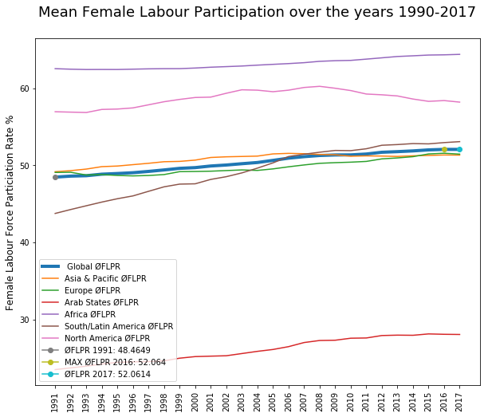

```python
# Plot line graphs of mean FLPRs
#parameters
plt.rcParams['figure.figsize']= [10,8]

# plot global average FLPR over time
plt.plot([str(i) for i in range(1991,2018)], df_comb.groupby('year')['flpr'].mean(), label=" Global ØFLPR", linewidth=4)

# plot regional average FLPR rates
regions = df_comb['region'].unique()
for region in regions:
    plt.plot([str(i) for i in range(1991,2018)], df_comb.query("region == @region").groupby('year')['flpr'].mean(), label= region + " ØFLPR")

# Marker year 1991
plt.plot(['1991'], df_comb.query('year == "1991"')['flpr'].mean(), marker='o', label="ØFLPR 1991: " +
         str(df_comb.query('year == "1991"')['flpr'].mean().round(4)))

# Marker highest FLPR
#calculate local max
flpr_max = max(df_comb.groupby('year')['flpr'].mean())
flpr_max_year = df_comb.groupby('year')['flpr'].mean().idxmax()
plt.plot(flpr_max_year, flpr_max, marker='o', label="MAX ØFLPR " + flpr_max_year +": " + str(round(flpr_max,4)))

# Marker year 2017
plt.plot(['2017'], df_comb.query('year == "2017"')['flpr'].mean(), marker='o', label="ØFLPR 2017: " + str(df_comb.query('year == "2017"')['flpr'].mean().round(4)))

#titles
plt.xlabel('')
plt.ylabel('Female Labour Force Particiation Rate %', fontsize=12)
plt.title('Mean Female Labour Participation over the years 1990-2017', fontsize=18).set_position([.5, 1.05])
plt.xticks(rotation='vertical')
plt.legend()
plt.show()
```

The above line graphs picture mean female labour participation rates over the period of 1991 to 2017. The highlighted graph describes the global mean, the other graphs show the mean FLPRs of the Asia & Pacific, Europe, Arab States, Africa, South/Latin America and North America.

We observe a modest increase of the global average FLPR over the time period of 1991 to 2017. In 1991 the mean FLPR was at 48.46%. By 2017 it had risen to 52.06% with a slight max. of 52.06% in the year 2016. Close to the global mean FLPR are Europe and Asian & Pacific States. The plot of South/Latin America shows a stronger increase than the average. In the early 90s South Americas FLPRs were at a bit more than 40%. By the mid 2000s, the FLPRs had risen above the levels of the global mean and are in 2017 at roughly 50%.

The far lowest mean FLPRs occur in Arab States. As a matter of fact, over the years we observe a relatively strong growth. Yet the Arab States average below 30%.

North America's female employment participation is above the global average. However, since 2008/2009 we also observe the strongest recession of all regions.

African women's employment participation outweighs by far other world regions with a rate at above 60%.

While the mean labour participation rates are interesting to observe global patterns, they don't tell us much about how divers the FLP rates across each world regions are. To visualize their diversity, we are going to use boxplot they year 2017.

```python
# Create separate dataframes for the years 1991 and 2017 and reindex
df_comb_1991 = df_comb.query('year == "1991"').reset_index(drop=True)
df_comb_2017 = df_comb.query('year == "2017"').reset_index(drop=True)

# Check the end of the dataframe. We shoul now see 175 entries.
df_comb_2017.tail(5)
```

|  | country | year | flpr | gni | region | dev_status |
| --- | --- | --- | --- | --- | --- | --- |
| 171 | Venezuela | 2017 | 50.2 | 12800.0 | South/Latin America | Global South |
| 172 | Vietnam | 2017 | 73.2 | 2170.0 | Asia & Pacific | Global South |
| 173 | Yemen | 2017 | 6.0 | 1030.0 | Arab States | Global South |
| 174 | Zambia | 2017 | 70.1 | 1300.0 | Africa | Global South |
| 175 | Zimbabwe | 2017 | 78.5 | 910.0 | Africa | Global South |

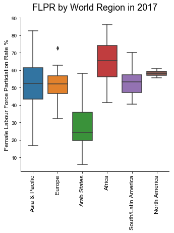

```python
# parameters
plt.rcParams['figure.figsize']= [12,10]

# Boxplot FLPR over world region
p = sns.catplot(x="region", y="flpr", kind="box", data=df_comb_2017)

# labels and titles
plt.title("FLPR by World Region in 2017", fontsize=18, pad=15)
plt.xlabel('', fontsize=12)
plt.ylabel('Female Labour Force Particiation Rate %', fontsize=12)
plt.xticks(rotation='vertical', fontsize=12)
p.set_xticklabels(rotation=90)
sns.set_style("whitegrid")
```

The boxplot of year 2017 FLPRs affirms our finding above. The graph of Arab States is comparatively low to other regions. Arab States tend to have lower female labour participation rates. The African region has a comparatively high boxplot. African women seem to engage at a higher rate in employment. Other region's FLPR medians average at a similar level, with North America having a bit higher median FLPR.

In addition to the line graphs above, we get an impression of the ranges of individual country's FLPR rates within a region. North America is comparatively the shortest, which indicates homogeneous FLPRs across states. Europe and South America show a moderate length of boxplots. Meaning, the countries tend to have relatively moderate homogenous FLPRs. The boxplots of Asian & Pacific have the longest tails. African and Arab States have also quite long tails, with Arab States being skewed to the right. The tails are an indication for a wide range of countries with very different FLPRs in respective regions.

**What were countries with the highest/lowest female labour participation rates in 1991 and 2017?**

I'm curious about finding out more details of FLPRs. Below, I'm investigating the countries with the highest and lowest female labour participation of the years 1991 and 2017.

*Countries of the highest female labour participation rates in 1991 and 2017*

```python
# Show the 10 countries with the highest female participation rates in the year 1991.
print("Countries in 1991 with the highest female labour participation rates.")
df_comb_1991.nlargest(10, 'flpr')
```

```
Countries in 1991 with the highest female labour participation rates.
```

|  | country | year | flpr | gni | region | dev_status |
| --- | --- | --- | --- | --- | --- | --- |
| 25 | Burundi | 1991 | 90.3 | 220.0 | Africa | Global South |
| 107 | Mozambique | 1991 | 87.1 | 200.0 | Africa | Global South |
| 130 | Rwanda | 1991 | 86.8 | 320.0 | Africa | Global South |
| 94 | Madagascar | 1991 | 84.2 | 220.0 | Africa | Global South |
| 154 | Tanzania | 1991 | 82.1 | 180.0 | Africa | Global South |
| 157 | Togo | 1991 | 80.8 | 400.0 | Africa | Global South |
| 110 | Nepal | 1991 | 80.7 | 210.0 | Asia & Pacific | Global South |
| 85 | Lao | 1991 | 79.9 | 210.0 | Asia & Pacific | Global South |
| 26 | Cambodia | 1991 | 77.1 | 250.0 | Asia & Pacific | Global South |
| 24 | Burkina Faso | 1991 | 76.3 | 360.0 | Africa | Global South |

```python
# Show the 10 countries with the highest female participation rates in the year 2017?
print("Countries in 2017 with the highest female labour participation rates.")
df_comb_2017.nlargest(10, 'flpr')
```

```
Countries in 2017 with the highest female labour participation rates.
```

|  | country | year | flpr | gni | region | dev_status |
| --- | --- | --- | --- | --- | --- | --- |
| 130 | Rwanda | 2017 | 86.0 | 720.0 | Africa | Global South |
| 94 | Madagascar | 2017 | 83.6 | 400.0 | Africa | Global South |
| 110 | Nepal | 2017 | 82.7 | 790.0 | Asia & Pacific | Global South |
| 107 | Mozambique | 2017 | 82.5 | 420.0 | Africa | Global South |
| 26 | Cambodia | 2017 | 80.9 | 1230.0 | Asia & Pacific | Global South |
| 25 | Burundi | 2017 | 80.2 | 290.0 | Africa | Global South |
| 154 | Tanzania | 2017 | 79.5 | 910.0 | Africa | Global South |
| 175 | Zimbabwe | 2017 | 78.5 | 910.0 | Africa | Global South |
| 53 | Ethiopia | 2017 | 77.2 | 740.0 | Africa | Global South |
| 85 | Lao | 2017 | 76.9 | 2270.0 | Asia & Pacific | Global South |

*Countries of the lowest female labour participation rates in 1991 and 2017*

```python
# Show the 10 countries with the lowest female participation rates in the year 1991.
print("Countries in 1991 with the lowest female labour participation rates.")
df_comb_1991.nsmallest(10, 'flpr')
```

```
Countries in 1991 with the lowest female labour participation rates.
```

|  | country | year | flpr | gni | region | dev_status |
| --- | --- | --- | --- | --- | --- | --- |
| 74 | Iraq | 1991 | 8.18 | 2020.0 | Arab States | Global South |
| 73 | Iran | 1991 | 9.85 | 1330.0 | Asia & Pacific | Global South |
| 119 | Palestine | 1991 | 10.20 | 1520.0 | Arab States | Global South |
| 80 | Jordan | 1991 | 10.90 | 1100.0 | Arab States | Global South |
| 2 | Algeria | 1991 | 11.50 | 1990.0 | Arab States | Global South |
| 118 | Pakistan | 1991 | 13.80 | 420.0 | Asia & Pacific | Global South |
| 133 | Saudi Arabia | 1991 | 14.20 | 8270.0 | Arab States | Global South |
| 0 | Afghanistan | 1991 | 14.90 | 210.0 | Asia & Pacific | Global South |
| 173 | Yemen | 1991 | 16.80 | 500.0 | Arab States | Global South |
| 87 | Lebanon | 1991 | 19.20 | 1780.0 | Arab States | Global South |

```python
# Show the 10 countries with the lowest female participation rates in the year 2017.
print("Countries in 2017 with the lowest female labour participation rates.")
df_comb_2017.nsmallest(10, 'flpr')
```

```
Countries in 2017 with the lowest female labour participation rates.
```

|  | country | year | flpr | gni | region | dev_status |
| --- | --- | --- | --- | --- | --- | --- |
| 173 | Yemen | 2017 | 6.0 | 1030.0 | Arab States | Global South |
| 152 | Syria | 2017 | 11.9 | 1840.0 | Arab States | Global South |
| 80 | Jordan | 2017 | 14.0 | 3980.0 | Arab States | Global South |
| 2 | Algeria | 2017 | 15.2 | 3960.0 | Arab States | Global South |
| 73 | Iran | 2017 | 16.8 | 5400.0 | Asia & Pacific | Global South |
| 74 | Iraq | 2017 | 18.7 | 4770.0 | Arab States | Global South |
| 0 | Afghanistan | 2017 | 19.5 | 570.0 | Asia & Pacific | Global South |
| 119 | Palestine | 2017 | 19.5 | 3180.0 | Arab States | Global South |
| 48 | Egypt | 2017 | 22.2 | 3010.0 | Arab States | Global South |
| 133 | Saudi Arabia | 2017 | 22.3 | 20100.0 | Arab States | Global South |

We find mostly Arab States and a few Asian/Pacific states amongst the top 10 lists of countries with the lowest FLPRs. Women hardly participated in the labour market in 1991 in Iraq (8.18%), followed by Iran (9.85%) and Palestine (10.20%). By 2017, we observe Yemen on the top with a rate of 6%, followed by Syria (11.9%) and Jordan (14%).  
Like in the list of the highest rated countries, we only have a few new members among the top 10 of 2017. Syria and Egypt entered the lowest ranks. Lebanon and Pakistan left the lowest rated female employment participation ranks.

What caught my eye here, is that among the Asian & Pacific States in the list of the lowest FLPR rates, are Iran and Afghanistan. Even though they belong geographically to Asia, we see mostly Islamic/Arab culture countries among the lowest FLPRs.

Let's visualize how the countries with the highest/lowest FLPR performed against the global mean.

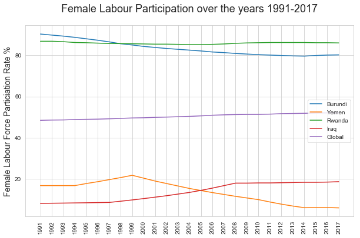

```python
# Create line plots of countries with lowest/highest rates in comparison to the global mean FLPR.
countries = ['Burundi', 'Yemen', 'Rwanda', 'Iraq']
plt.rcParams['figure.figsize']= [10,6]
for country in countries:
    plt.plot(df_comb.query('country == @country')['year'],df_comb.query('country == @country')['flpr'], label=country)

# plot global mean
plt.plot([str(year) for year in range(1991,2018)], df_comb.groupby('year')['flpr'].mean(), label="Global")

# titles and labels
plt.xlabel('')
plt.ylabel('Female Labour Force Particiation Rate %', fontsize=14)
plt.title("Female Labour Participation over the years 1991-2017", fontsize=18).set_position([.5, 1.05])
plt.rcParams['figure.figsize']= [10,6]
plt.xticks(rotation='vertical')
plt.legend()
plt.show()
```

The graph illustrates the wide range of levels of women's employment participation rates around the globe. While Burundi and Rwanda show FLP rates near 90 %, Yemen goes down to 6% in the year 2017.

The global mean shows only a modest tendency to rise, Yemen, Iraq and Burundi experienced more severe changes over the years 1991 to 2017. Let's find out what countries experienced the biggest changes compared to 1991.

*In what regions do we encounter the biggest changes of labour participation?*

```python
# Formula to calculate growth rates of FLPR compared to 1991.
def calc_growth(row, col):
    val_latest = row[col]
    val_1991 = df_comb.query('(country ==@row.country) & (year == "1991")').iloc[0][col]
    change_rate = ((val_latest - val_1991) / val_latest) * 100
    return change_rate

# Create new column 'flpr_change' with each cell containing the growth compared to 1991
df_comb_2017['flpr_change'] = df_comb_2017.apply(lambda row: calc_growth(row, 'flpr'), axis=1)
df_comb_2017.tail()
```

|  | country | year | flpr | gni | region | dev_status | flpr_change |
| --- | --- | --- | --- | --- | --- | --- | --- |
| 171 | Venezuela | 2017 | 50.2 | 12800.0 | South/Latin America | Global South | 15.139442 |
| 172 | Vietnam | 2017 | 73.2 | 2170.0 | Asia & Pacific | Global South | 0.000000 |
| 173 | Yemen | 2017 | 6.0 | 1030.0 | Arab States | Global South | -180.000000 |
| 174 | Zambia | 2017 | 70.1 | 1300.0 | Africa | Global South | -5.278174 |
| 175 | Zimbabwe | 2017 | 78.5 | 910.0 | Africa | Global South | 13.630573 |

```python
# What countries had the greatest positive FLPR growth from 1991 to 2017?
df_comb_2017.nlargest(10, 'flpr_change')
```

|  | country | year | flpr | gni | region | dev_status | flpr_change |
| --- | --- | --- | --- | --- | --- | --- | --- |
| 74 | Iraq | 2017 | 18.7 | 4770.0 | Arab States | Global South | 56.256684 |
| 97 | Maldives | 2017 | 42.9 | 9570.0 | Asia & Pacific | Global South | 49.417249 |
| 34 | Colombia | 2017 | 58.8 | 5830.0 | South/Latin America | Global South | 48.299320 |
| 119 | Palestine | 2017 | 19.5 | 3180.0 | Arab States | Global South | 47.692308 |
| 118 | Pakistan | 2017 | 24.9 | 1580.0 | Asia & Pacific | Global South | 44.578313 |
| 98 | Mali | 2017 | 60.8 | 770.0 | Africa | Global South | 41.776316 |
| 73 | Iran | 2017 | 16.8 | 5400.0 | Asia & Pacific | Global South | 41.369048 |
| 32 | Chile | 2017 | 50.6 | 13600.0 | South/Latin America | Global South | 36.956522 |
| 123 | Peru | 2017 | 69.0 | 5970.0 | South/Latin America | Global South | 36.956522 |
| 133 | Saudi Arabia | 2017 | 22.3 | 20100.0 | Arab States | Global South | 36.322870 |

```python
# What countries experienced the biggest decrease of female labour participation?
df_comb_2017.nsmallest(10, 'flpr_change')
```

|  | country | year | flpr | gni | region | dev_status | flpr_change |
| --- | --- | --- | --- | --- | --- | --- | --- |
| 173 | Yemen | 2017 | 6.0 | 1030.0 | Arab States | Global South | -180.000000 |
| 152 | Syria | 2017 | 11.9 | 1840.0 | Arab States | Global South | -89.915966 |
| 156 | Timor-Leste | 2017 | 24.9 | 1790.0 | Asia & Pacific | Global South | -76.305221 |
| 128 | Romania | 2017 | 44.1 | 9970.0 | Europe | Global North | -41.043084 |
| 24 | Burkina Faso | 2017 | 58.1 | 610.0 | Africa | Global South | -31.325301 |
| 71 | India | 2017 | 27.2 | 1820.0 | Asia & Pacific | Global South | -29.411765 |
| 103 | Moldova | 2017 | 39.4 | 2180.0 | Europe | Global North | -20.304569 |
| 108 | Myanmar | 2017 | 51.3 | 1190.0 | Asia & Pacific | Global South | -19.493177 |
| 33 | China | 2017 | 61.5 | 8690.0 | Asia & Pacific | Global South | -18.861789 |
| 145 | Sri Lanka | 2017 | 35.1 | 3840.0 | Asia & Pacific | Global South | -18.518519 |

**Did any world region's FLPR growth overperform or underperform over the period of 1991-2017?**

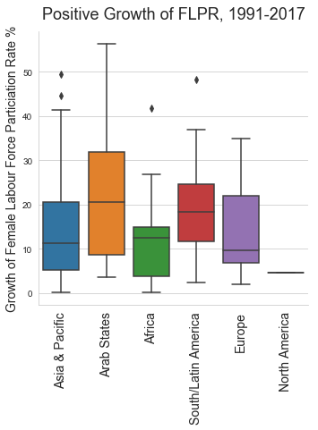

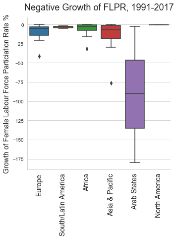

```python
# plot change rates by world region
# parameters
plt.rcParams['figure.figsize']= [12,10]

# boxplot positive growth rates
p1 = sns.catplot(x="region", y="flpr_change", kind="box", data=df_comb_2017[df_comb_2017['flpr_change'] > 0])

# labels and titles
plt.title("Positive Growth of FLPR, 1991-2017", fontsize=18, pad=15)
plt.xlabel('')
plt.ylabel('Growth of Female Labour Force Particiation Rate %', fontsize=14)
plt.xticks(rotation='vertical', fontsize=14)
p1.set_xticklabels(rotation=90)

# boxplot negative growt rates
p2 = sns.catplot(x="region", y="flpr_change", kind="box", data=df_comb_2017[df_comb_2017['flpr_change'] <= 0])

# labels and titles
plt.title("Negative Growth of FLPR, 1991-2017", fontsize=18, pad=15)
plt.xlabel('')
plt.ylabel('Growth of Female Labour Force Particiation Rate %', fontsize=14)
plt.xticks(rotation='vertical', fontsize=14)
p1.set_xticklabels(rotation=90)
plt.show()
```

Investigating growth rates of female labour force participation, we find one outstanding area: Arab States. They show the longest tails and highest interquartile ranges for both: positive and negative development. The difference towards other regions is especially significant at decreasing growth rates. Whereas all other regions show relatively minimal interquartile ranges of above -25%, Arab States' lower whisker is at below -175%.  
Positive growth is much stronger across all regions, except in Arab States. After the Arab States, South America shows the second highest growth rates. North America's median growth was the lowest at about 5%.

*Is the FLPR different in the Global North and Global South?*  
We noticed the level of female labour participation rates is roughly connected to world regions. Taking a closer look at specific world regions may result in very diverse female labour participation rates. This is especially true for Asian & Pacific states. One factor that might influence the FLPR is the political and socio-economic region of a country. We can divide the world in Global North for the developed world and Global South for the developing world. To visualize the connection, we are going to use a boxplot.

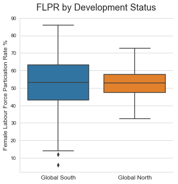

```python
# Boxplot FLPR according to their development status
p = sns.catplot(x="dev_status", y="flpr", kind="box", data=df_comb_2017)

# titles and labels
plt.title("FLPR by Development Status", fontsize=18, pad=15)
plt.xlabel('')
plt.ylabel('Female Labour Force Particiation Rate %', fontsize=12)
plt.rcParams['figure.figsize']= [10,8]
plt.xticks(fontsize=12)

plt.show()
```

Both groups Global North and Global South have their median on one level at slightly above 50%. Compared to the Global North, the Global South has a longer interquartile range and longer tails with a few outliers in the low percentage FLPR. It shows extremes to occur rather in the Global South. The developed world tends to have rather mediocre female labour participation rates.

As Global North and Global South are a political and socio-economic description of the world, I suspect the economic situation of a country could drive female employment participation. Below, I am going to further investigate the relationship.

### Does a country's economic situation drive female employment participation?

To find out the relationship between female employment participation and the economic situation of a country, I will analyse two factors. First, the Gross National Income (GNI) of a country and second the labour market's industry distribution.

The GNI describes the total domestic and foreign output of all residents of a country. It is a measure to helps us compare the economic activities across regions. Using the GNI, I am going to investigate whether there is a pattern of poor or rich countries having higher or lower female participation rates.

I am going to describe a country's industry by analysing the distribution of its economic sectors: service, agriculture and industry. The aim is to examine if there a correlation between female employment participation and a dominant economic sector? Is the type of work women engage in connected to a regions overall female labour participation?

**Does poor and rich country's female labour participation rates perform differently?**

```python
# Let's take a look at the GNI.
df_comb['gni'].describe()
```

```
count      4752.000000
mean       8993.902567
std       14450.303994
min          80.000000
25%         760.000000
50%        2610.000000
75%        9747.500000
max      105000.000000
Name: gni, dtype: float64
```

The global average GNI over the years 1991 to 2017 is 8993.9 USD per capita, ranging from 80 USD to 105000 USD. Let's find out how the global GNI developed over the past period.

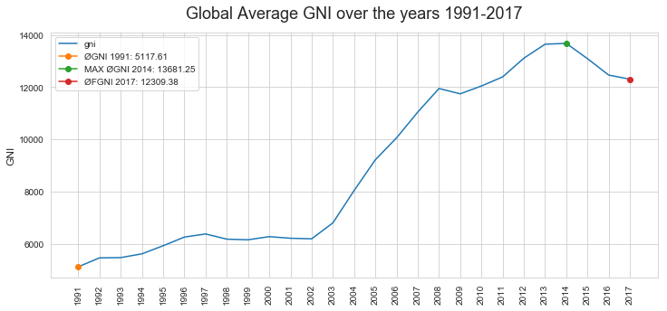

```python
# parameters
plt.rcParams['figure.figsize']= [12,5]

# plot the global GNI by year
plt.plot([str(i) for i in range(1991,2018)], df_comb.groupby('year')['gni'].mean())

# Marker year 1991
plt.plot(['1991'], df_comb.query('year == "1991"')['gni'].mean(), marker='o', label="ØGNI 1991: " +
         str(df_comb.query('year == "1991"')['gni'].mean().round(2)))

# Marker highest FLPR
#calculate local max
gni_max = max(df_comb.groupby('year')['gni'].mean())
gni_max_year = df_comb.groupby('year')['gni'].mean().idxmax()
plt.plot(gni_max_year, gni_max, marker='o', label="MAX ØGNI " + gni_max_year +": " + str(round(gni_max,2)))

# Marker year 2017
plt.plot(['2017'], df_comb.query('year == "2017"')['gni'].mean(), marker='o', label="ØFGNI 2017: " + str(df_comb.query('year == "2017"')['gni'].mean().round(2)))

# titles and labels
plt.title('Global Average GNI over the years 1991-2017', fontsize=18, pad=15)
plt.xlabel('')
plt.ylabel('GNI', fontsize=12)
plt.xticks(rotation='vertical')
plt.legend()
plt.show()
```

Compared to the global FLPR, the GNI shows a more significant increase from 1991 to 2017. The global GNI more than doubled in 27 years. In 1991 the global GNI was at 5117.6 USD. By 2017 it had risen to 12309.4 USD. We observe a steap increase since the early 2000s. It peaks in the year 2014 at 13681.25 USD and declines thereafter.

To find out if there is a relationship between the global FLPR and GNI we visualize the 2017 data in a scatter plot.

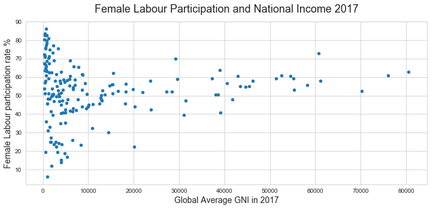

```python
# scatterplot FLPR against global average GNI
df_comb.query("year == '2017'").plot(x='gni', y='flpr',kind='scatter')

#titles and labels
plt.title('Female Labour Participation and National Income 2017', fontsize=18, pad=15)
plt.xlabel('Global Average GNI in 2017', fontsize=14)
plt.ylabel('Female Labour participation rate %', fontsize=14)
plt.show()
```

The above figure shows that extreme high or low FLPRs occur mainly at a low Gross National Income. There is a bulk of countries with low incomes. We also notice that most FLPR are roughly between 40-65%.

To remove noise and express the relationship between GNI and FLPR clearer, it makes sense to look on low income and high income countries separately. We are using the percentiles 25%, 50%, 75% and the maximum value to bucket FLPR rates and GNI in very low, low, moderately high and high categories.

```python
# Find quartiles of GNI
df_comb_2017['gni'].describe()
```

```
count      176.000000
mean     12309.375000
std      17052.404947
min        290.000000
25%       1722.500000
50%       4760.000000
75%      14475.000000
max      80600.000000
Name: gni, dtype: float64
```

```python
# Find quartiles of FLPR
df_comb_2017['flpr'].describe()
```

```
count    176.000000
mean      52.061364
std       15.662366
min        6.000000
25%       45.100000
50%       53.100000
75%       60.900000
max       86.000000
Name: flpr, dtype: float64
```

```python
# Create bins for GNI's and FLPR using percentiles
bins_gni = [290.000000, 1722.500000, 4760.000000, 14475.000000, 80600.000000]
bins_flpr = [ 6.000000, 45.100000, 53.100000, 60.900000, 86.000000]
bin_labels = ['very low', 'low', 'moderately high', 'high']

# Create categorial variable from continuous variables and save it to new columns
df_comb_2017['gni_level'] = pd.cut(df_comb_2017['gni'], bins_gni, labels=bin_labels, include_lowest=True)
df_comb_2017['flpr_level'] = pd.cut(df_comb_2017['flpr'], bins_flpr, labels=bin_labels,include_lowest=True)
```

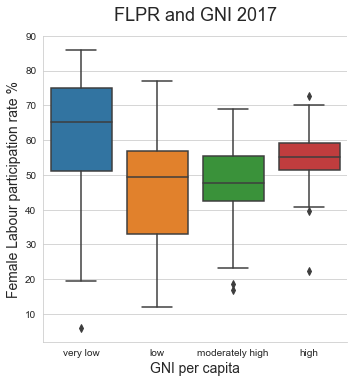

```python
# Boxplot FLPR to their GNI level
sns.catplot(x="gni_level", y="flpr", kind="box", data=df_comb_2017)

# titles and labels
plt.title("FLPR and GNI 2017", fontsize=18, pad=15)
plt.xlabel('GNI per capita', fontsize=14)
plt.ylabel('Female Labour participation rate %', fontsize=14)
plt.show()
```

Let's find out the details of how female participation labour rates vary according to country's of very low, low, moderately high and high national incomes.

```python
# Count occurences of very low, low, moderately high or high FLPRs at a given GNI level.
flpr_counts = []
for level in bin_labels:
    levels = [len(df_comb_2017.query('(gni_level == @level) & (flpr_level == @label)').index) for label in bin_labels]
    flpr_counts.append(levels)

# turn into a dictionary
categories = dict(zip(bin_labels, flpr_counts))

# turn into a dataframe
df_cat = pd.DataFrame(categories, index=['very low FLPR', 'low FLPR', 'moderately high FLPR', 'high FLPR'])

# rename columns
new_cols = df_cat.columns
new_cols = list(map(lambda x: x[:15] + " GNI", new_cols))
df_cat.columns = new_cols

df_cat
```

|  | very low GNI | low GNI | moderately high GNI | high GNI |
| --- | --- | --- | --- | --- |
| very low FLPR | 6 | 17 | 17 | 5 |
| low FLPR | 6 | 12 | 12 | 13 |
| moderately high FLPR | 5 | 8 | 10 | 21 |
| high FLPR | 27 | 7 | 5 | 5 |

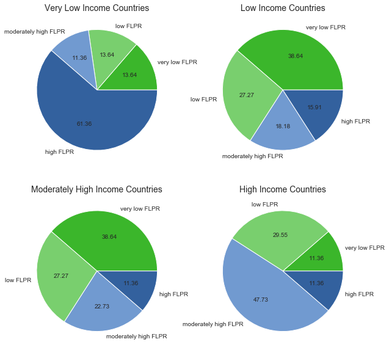

```python
# Create pie plots, two on each axes.
fig, ((ax1, ax2), (ax3, ax4)) = plt.subplots(nrows=2, ncols=2, figsize=(10,10))

# use green tone for low FLPR rates, use blue tone for high FLPR rates
colors = ['#3bb62b', '#79cf6e', '#719ad0', '#33619e']

# create pie plots
ax1.pie(df_cat['very low GNI'], labels=df_cat.index, colors=colors, autopct='%.2f' )
ax2.pie(df_cat['low GNI'], labels=df_cat.index, colors=colors,autopct='%.2f')
ax3.pie(df_cat['moderately high GNI'], labels=df_cat.index, colors=colors, autopct='%.2f')
ax4.pie(df_cat['high GNI'], labels=df_cat.index, colors=colors, autopct='%.2f')

# titles
ax1.set_title("Very Low Income Countries", fontsize=14)
ax2.set_title("Low Income Countries", fontsize=14)
ax3.set_title("Moderately High Income Countries", fontsize=14)
ax4.set_title("High Income Countries", fontsize=14)
plt.show()
```

The pie charts above illustrate how FLPR rates are distributed according to their economic income.  
Over 61% of very poor countries tend to have very high female participation rates. Low income and moderately high income countries have a similar distribution of FLPR rates. About 38% of the latter have very low female labour participation rates, another 27% have low labour participation rates. Only about one third of those countries have moderately high to high FLPRs. The picture changes significantly in rich countries. We predominantly find countries at moderately high FLPRs (47.73 %). In comparison to moderately high income countries, there are fewer countries of very low FLPRs (11.4 % compared to 38.6%).

We now know how the employment rates are distributed of poor and rich countries. To find out what the situation is like for the majority of women in the world, we have to count in the population size of a country.

```python
# merge population into 2017 combined dataframe
df_comb_2017 = pd.merge(df_comb_2017, df_pop, how='inner', left_on=['country'], right_on=['country'])

# rename column
df_comb_2017 = df_comb_2017.rename(index=str, columns={'2017': 'f_population'})
df_comb_2017.head(1)
```

|  | country | year | flpr | gni | region | dev_status | flpr_change | gni_level | flpr_level | f_population |
| --- | --- | --- | --- | --- | --- | --- | --- | --- | --- | --- |
| 0 | Afghanistan | 2017 | 19.5 | 570.0 | Asia & Pacific | Global South | 23.589744 | very low | very low | 17200000 |

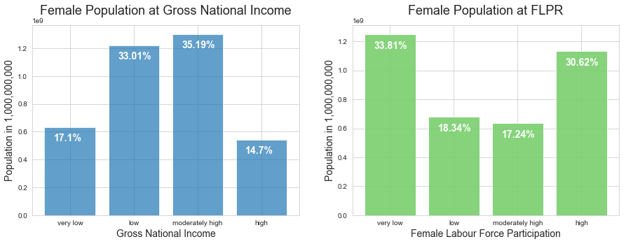

```python
# Visualize absolute numbers of women living in countries of a certain GNI and FLPR

# Create  figure with two subplots in one row
fig, (ax1, ax2) = plt.subplots(nrows=1, ncols=2, figsize=(15,5))

# Create bar plots
ax1.bar(bin_labels, df_comb_2017.groupby('gni_level')['f_population'].sum(axis=1), alpha=0.7)
ax2.bar(bin_labels, df_comb_2017.groupby('flpr_level')['f_population'].sum(axis=1), alpha=0.9, color='#79cf6e')

# Create titels, name axis
ax1.set_title('Female Population at Gross National Income', fontsize=18, pad=15)
ax1.set_xlabel('Gross National Income', fontsize=14)
ax1.set_ylabel("Population in 1,000,000,000", fontsize=14)
ax2.set_title('Female Population at FLPR', fontsize=18, pad=15)
ax2.set_xlabel('Female Labour Force Participation',  fontsize=14)
ax2.set_ylabel("Population in 1,000,000,000", fontsize=14)

# Annotate total numbers

# count totals
fpop_total = sum(df_comb_2017['f_population'])

for i in ax1.patches:
    ax1.text(i.get_x()+.15, i.get_height()-100000000, str(round((i.get_height()/fpop_total)*100,2)) + '%', fontsize=14, color='white', weight='bold')
for i in ax2.patches:
    ax2.text(i.get_x()+.15, i.get_height()-100000000, str(round((i.get_height()/fpop_total)*100,2)) + '%', fontsize=14, color='white', weight='bold')

plt.show()
```

In 2017 most women lived in states of moderately high (35.19%) or low (33.01%) income. At the same time, most women (33.81%) lived in countries of very low employment participation rates under 45.1%. 30.62% of all women lived in countries of high FLPR, meaning they live at employment participation rates between 60.9 to 86%.

```python
print("Considered global female population of this report: {}.".format(fpop_total))
```

```
Considered global female population of this report: 3698561700.
```

```python
df_comb_2017.query('(country == "China") | (country == "India")')
```

|  | country | year | flpr | gni | region | dev_status | flpr_change | gni_level | flpr_level | f_population |
| --- | --- | --- | --- | --- | --- | --- | --- | --- | --- | --- |
| 33 | China | 2017 | 61.5 | 8690.0 | Asia & Pacific | Global South | -18.861789 | moderately high | high | 683000000 |
| 71 | India | 2017 | 27.2 | 1820.0 | Asia & Pacific | Global South | -29.411765 | low | very low | 645000000 |

China's female population is about 18.5%, India's 17.4% of the total global female population considered in this report.  
China has a moderately high income and also a high number of female employment. India on the other hand has a very low FLPR level at a low national income. The extraordinary size of both countries compared to the rest of the world may bias the findings of the FLPR rates compared to the GNI. While the findings may show a relationship, our findings may not explain the situation of the majority of women in the world.

To visualize the amount if women living under the investigated conditions, we are going to consider the population size in our scatter plot.

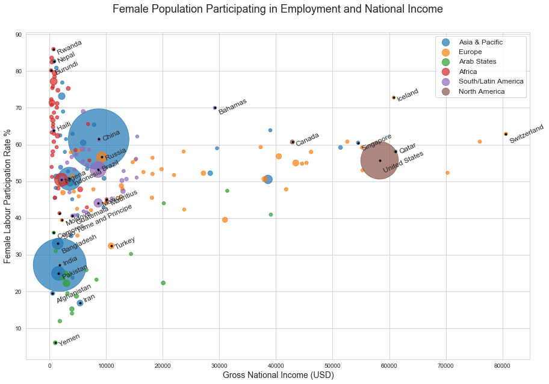

```python
# Create scatterplot considering population sizes.
# calculate markersizes for each region
def get_markersize(population_series):
    # reduce markersize for large populations (China and India) to avoid overplotting
    m = [30*3**(n*100 / fpop_total) if n < 600000000 else 80*1.3**(n*100 / fpop_total) for n in population_series]
    return m

# figure size
plt.rcParams['figure.figsize']= [15,10]

# List of all regions of our dataset
regions = df_comb_2017['region'].unique()

# Highlight remarkable countries: start by adding 10 largest populated nations
countries = ['China', 'India', 'Indonesia','Brazil', 'United States','Nigeria', 'Pakistan', 'Russia', 'Mexico', 'Bangladesh']

# plots for every country, assigning one color for each world region
for region in regions:
    # calculate markersize for each country
    m = get_markersize(df_comb_2017.query("region == @region")['f_population'])
    plt.scatter(df_comb_2017.query("region == @region")['gni'], df_comb_2017.query("region == @region")['flpr'], label=region,alpha=.7,s=m)
    # add extreme-value countries of every region to our country highlighting list
    countries.append(df_comb_2017.query('region == @region').nlargest(1, 'flpr').iloc[0]['country'])
    countries.append(df_comb_2017.query('region == @region').nsmallest(1, 'flpr').iloc[0]['country'])
    countries.append(df_comb_2017.query('region == @region').nlargest(1, 'gni').iloc[0]['country'])
    countries.append(df_comb_2017.query('region == @region').nsmallest(1, 'gni').iloc[0]['country'])

# titles and labels
plt.title('Female Population Participating in Employment and National Income', fontsize=18).set_position([.5, 1.05])
plt.xlabel('Gross National Income (USD)', fontsize=14)
plt.ylabel('Female Labour Participation Rate %', fontsize=14)
legend = plt.legend(fontsize=12)

# Reduce legend marker sizes of Asia & Pacific and North America
for i in range(6):
    legend.legendHandles[i]._sizes = [150]

# Remove duplicates in the country highlight list while keeping the order
u_countries = []
list(map(lambda country: u_countries.append(country) if country not in u_countries else None, countries))

# create a list of coordinates of highlight countries
x_coords = [df_comb_2017.query('country == @country').iloc[0]['gni'] for country in u_countries]
y_coords = [df_comb_2017.query('country == @country').iloc[0]['flpr'] for country in u_countries]

# annotate highlight countries
for i,country in enumerate(u_countries):
    x = x_coords[i]
    y = y_coords[i]
    plt.scatter(x, y, marker='.', color='black')
    plt.text(x+500, y+1.5, country, fontsize=12, rotation=25)
plt.show()
```

Please be aware that the population sizes of China and India are severely underestimated. To avoid overlap their size was drastically reduced.

The graph above illustrates that the overwhelming majorty of women live in countries of comparitively low income rates. There is a clear trend of African countries of very low income having comparatively high employment participation rates. On the lower end, we mostly find Arab States and some Southwest Asian States (e.g. Iran, Afghanistan, Pakistan, India).

European and North American countries have much higher income rates an score mostly moderately at the FLPR scale.

**Does female employment participation depend on the branches of trade of a country?**

This part of the research is looking into the sectors of female employment around the globe. Do women typically work in the industrial, agriculture or service sector? Are FLPRs typically higher or lower, if there is a dominant economic branch in a region?

We are going to start by looking at the global means of each sector and how they developed over time. First, we will line plot each sector over the period 1991-2017. We will add pie charts of the years 1991 and 2017 to visualize the composition of the female labour market 1991 and 2017.

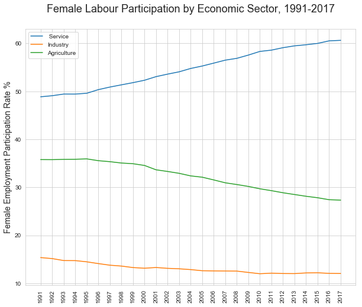

```python
# Plot line graphs of mean FLPRs
#parameters
plt.rcParams['figure.figsize']= [10,8]

# plot global development of service sector
plt.plot([str(i) for i in range(1991,2018)], df_sectors.groupby('year')['service'].mean(), label=" Service")
# plot global development of service sector
plt.plot([str(i) for i in range(1991,2018)], df_sectors.groupby('year')['industry'].mean(), label="Industry")
plt.plot([str(i) for i in range(1991,2018)], df_sectors.groupby('year')['agriculture'].mean(), label="Agriculture")

#titles
plt.xlabel('')
plt.ylabel('Female Employment Participation Rate %', fontsize=14)
plt.title('Female Labour Participation by Economic Sector, 1991-2017', fontsize=18).set_position([.5, 1.05])
plt.xticks(rotation='vertical')
plt.legend()
plt.show()
```

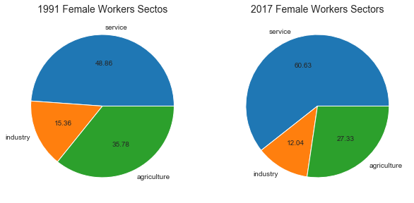

```python
# Create pie plots, two on each axes.
fig, (ax1, ax2) = plt.subplots(nrows=1, ncols=2, figsize=(10,10))

# calculate totals of industry, service, agriculture
industries_1991 = df_sectors.query('year == "1991"').loc[:, ['service', 'industry', 'agriculture']].sum()
industries_2017 = df_sectors.query('year == "2017"').loc[:, ['service', 'industry', 'agriculture']].sum()


# pie plots
ax1.pie(industries_1991, labels=industries_1991.index, autopct='%.2f' )
ax2.pie(industries_2017, labels=industries_2017.index, autopct='%.2f' )

# titles
ax1.set_title("1991 Female Workers Sectos", fontsize=14)
ax2.set_title("2017 Female Workers Sectors", fontsize=14)

plt.show()
```

The global average female labour market changed in the period of 1991 to 2017. By 2017, the service sector is globally the most meaningful economic sector of female employment (60.63%). It's importance has grown significantly. In comparison to 1991 the percentage of women working in the service sector is 12% higher. The growth mostly happened at the cost of the agricultural sector, which is about 8% less compared to 1991. The industrial sector is comparatively small in female employment. Since 1991 it has decreased from 15.4% to 12% in the year 2017.

```python
# combine sectors with our combined dataframe
df_comb_2017 = pd.merge(df_comb_2017, df_sectors, how='inner', left_on=['country', 'year'], right_on=['country', 'year'])
```

```python
# analyse sectors
sectors = ['service', 'industry', 'agriculture']

# get population for each FLPR level
sorted_sectors = df_comb_2017.groupby('flpr_level', as_index=False)['f_population'].sum()

# add mean percentages of sectors of very low, low, moderately high and high FLPR countries
for sector in sectors:
    right = df_comb_2017.groupby('flpr_level', as_index=False)[sector].mean()
    sorted_sectors = pd.merge(sorted_sectors, right)

sorted_sectors
```

|  | flpr_level | f_population | service | industry | agriculture |
| --- | --- | --- | --- | --- | --- |
| 0 | very low | 1250325900 | 60.277778 | 15.592000 | 24.131867 |
| 1 | low | 678256000 | 70.695349 | 12.888837 | 16.414605 |
| 2 | moderately high | 637488500 | 75.461364 | 11.230091 | 13.315864 |
| 3 | high | 1132491300 | 39.788409 | 8.524477 | 51.683409 |

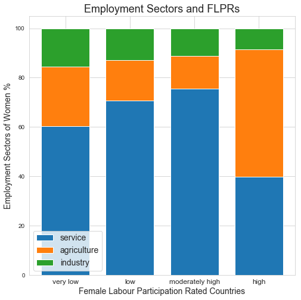

```python
# parameters
width = 0.75
plt.rcParams['figure.figsize']= [8,8]

# Create stacked bar plots
p1 = plt.bar(bin_labels, sorted_sectors['service'], width)
p2 = plt.bar(bin_labels, sorted_sectors['agriculture'], width, bottom=sorted_sectors['service'])
p3 = plt.bar(bin_labels, sorted_sectors['industry'], width, bottom=sorted_sectors['service']+sorted_sectors['agriculture'])

# titles
plt.xlabel('Female Labour Participation Rated Countries', fontsize=14)
plt.ylabel('Employment Sectors of Women %', fontsize=14)
plt.title('Employment Sectors and FLPRs', fontsize=18)
plt.xticks(fontsize=12)
plt.legend((p1[0], p2[0], p3[0]), ('service', 'agriculture', 'industry'), prop={'size': 14}, loc=3)
plt.show()
```

With increasing female labour participation rates we observe a change of the composition of the labour market. From countries of very low to moderately high FLPRs, the service sector participation grows at the cost of the agricultural and industrial sector. The three categories show a dominant service sector, a smaller agricultural sector and an even smaller industrial sector. In countries of moderately high female labour participation a mean of 75.5% of women engage in the service industry, 13.3% in agriculture and 11.2% in industrial work.

If we look at countries of highest participation rates, the trend turns around. Following the trend, we would expect an even higher employment in service. Instead, women are mostly employed in agricultural work (51.7%) and are outweighing the service sector (39.8%).

```python
df_comb_2017.shape
```

```
(176, 13)
```

## Conclusions

### Does any region's female labour force participation outperform other regions?

Over the period of 1991 to 2017, we observed female labour force participation rates in 176 countries ranging from 6% to 90.3%. To observe patterns across regions, we segmented our country data into the world regions Asia & Pacific, South/Latin America, North America, Europe, Africa and Arab States. We observe a slow increase of the global average FLPRs. In 1991, the mean FLPR was at 48.5%. By 2017, it had risen to 52.1%.

We observed trends of female participation rates that are particular to a world region. However, the variation of female labour participation rates may vary strongly within one world region.

African countries tend to have the highest mean female labour force participation. Among the most extreme FLPRs, we mostly find African states and a few Asian & Pacific States. In 2017, Rwanda reached the top FLPR of 86%, followed by Madagascar (83.6%) and Nepal (82.7%).

Female labour particpation rates of Arab States underperform significantly. We find the lowest rates mostly in Arab States. In 2017, Yemen had the lowest rate at 6%, followed by Syria (11.9%) and Jordan (14%). Among the lowest rates is also a noticeable number of Southwest-Asian states like Iran, Afghanistan and Pakistan.

The strongest growth of FLPR was observed in Iraq. By 2017, it had increased by 56.3%. On the other hand, Yemen (-180%) and Syria (-89.91%) experienced dramatic decreased female labour participation rates.

The growth rates of Arab States outperformed other regions in both directions. They have significant occurrences of both, extremely positive and negative growth rates. North America was significant in the respect of its median growth. As a region, it was comparatively low at about 5%. We even observe a slightly negative trend since the mid 2000s.

If we divide the world by their developmental status of Global North and Global South, we find the Global South to be more heterogeneous in terms of their FLPRs. Extremes tend to occur rather in the Global South. The developed world tends to have rather mediocre female labour participation rates.

### Does a country's economic situation drive female employment participation?

To investigate the economic situation of a country and its female labour participation, we explored the country's gross national incomes and their economic sectors.

Compared to the global FLPR, the GNI shows a more significant growth from 1991 to 2017. The global GNI more than doubled in 27 years. We observed a strong increase in the early 2000s until the year 2014, thereafter it declines. The global FLPR however shows a constant, relatively slow positive trend. The global relationship of these factors seems to be rather weak if any.

Comparing female labour participation rates against a country's economic output directly, results in u-shaped curve. In very poor countries women tend to participate at high levels in employment. The average FLPR drops for low income and moderately high income countries to mostly very low and low rates. However, the mean FLPRs are slightly increasing at moderately high GNI rates. In rich countries the trend changes towards reversed direction. Country's of moderately high female labour participation outweigh lower rated countries. Yet, rich country's FLPRs don't reach high rates like the poorest countries.

We observe strong variations of FLP rates within different income groups. Especially in very low and low income countries the FLPRs are not consistent at country level. For example, Afghanistan and Cambodia are both very poor countries. Yet, Afghanistan has a rate of 19.5%, while Cambodia a rate of 80.9%. The data suggests the possibility of additional socio-economic, political or cultural factors that drive the degree to which women participate in employment.

One other factor could be the type of work that is in demand in an economy. We found out that country's of high female labour participation typically have an unusually dominant agriculture sector (51.7%) compared to service and industry sectors. In all other country's from low to moderately high female labour participation, agricultural employment has a relatively low importance. With rates at 60.3 to 75.5% the service sector outweighs by far the agricultural sector.

In this report we found out that female labour participation varies across the globe significantly. There are patterns of the percentages of female labour participation across regions and according to a country's economy. However, the correlation with the strength of an economy is not straightforward in any case. It is especially insignificant for low to moderately high income countries. There are divergent FLPRs within regions and across different economic outputs. In this respect, we are inspired to ask what other socio-economic, political or cultural factors may drive female labour participation.

We have to handle the above results with caution. According to ilostat, female labour participation has been poorly measured and widely underestimated. On the one hand, female work is often not considered as employment. On the other hand, often men report on behalf of women when responding to surveys. In this respect, we expect the data to be biased towards a male view on employment. Another fact that may bias our findings are divergent population numbers of countries. China with 683 million women has the same weight as Montenegro with a population of only 319,000 women. We may expect that the FLPR within a large country like China may vary internally. As we've seen in our research above, this reports findings hold true on a country level, yet may change if we want to describe the situation of women in absolute population numbers.

### Resources

The datasets were downloaded from Gapminder. https://www.gapminder.org/data/

Further research about the data's details was done at the data provider's websites of ilostat and World Bank. https://data.worldbank.org/indicator/NY.GNP.PCAP.CD https://www.ilo.org/ilostat-files/Documents/description_LFPR_EN.pdf

The list of countries by regional classification was taken from Wikimedia. Wikimedia, https://meta.wikimedia.org/wiki/List_of_countries_by_regional_classification

Articles used that inspired this report/ https://wol.iza.org/articles/female-labor-force-participation-in-developing-countries/long https://ourworldindata.org/female-labor-force-participation-key-facts https://howwegettonext.com/gdp-sucks-here-are-some-better-alternatives-88cf2bfec017